# Date

Humoon

2022-03-22

```r
library(lubridate)
library(nycflights13)
library(hms)
```

## 基础包

获取系统日期：`Sys.Date()` 获取系统时间：`Sys.time()`

格式化时间

```r
(m = Sys.Date())
```

```
#> [1] "2022-03-22"
```

```r
format(m, format = "%B %d %Y")  # 改成月日年的格式
```

```
#> [1] "三月 22 2022"
```

```r
format(m, format = "%B %d %Y %A")  # 加入星期信息
```

```
#> [1] "三月 22 2022 星期二"
```

```r
format(m, format = "%B")  # 只提取出月份信息
```

```
#> [1] "三月"
```

```r
format(Sys.time(), format = "%Y/%B/%a %H:%M:%S")  # 提取部分时间信息
```

```
#> [1] "2022/三月/周二 11:08:52"
```

## 使用 lubricate 包处理日期和时间

**lubridate cheatsheet.pdf**

[figure not shown]

表示日期或时间的数据有 3 种类型：  
- 日期：在 tibble 中显示为`<date>`  
- 时间：一天中的某个时刻，在 tibble 中显示为`<time>`  
- 日期时间：可以唯一标识某个时刻（通常精确到秒）的日期加时间，在 tibble 中显示为`<dttm>`

要想得到当前日期或当前日期时间，你可以使用 `today()` 或 `now()` 函数：

```r
today()
```

```
#> [1] "2022-03-22"
```

```r
now()
```

```
#> [1] "2022-03-22 11:09:23 CST"
```

### 创建日期或时间

#### 通过字符串创建

`ymd()`**系列函数**是从字符串创建单个日期时间对象的最简方法，也可以接受不带引号的数值。它不需要指定参数，便能自动处理标点和月份、星期的英文全称、缩写。

```r
x = c(20090101, "2009-01-02", "2009 01 03", "2009-1-4", "2009-1,5", "Created on 2009 1 6", "200901 !!! 07")
ymd(x)
```

```
#> [1] "2009-01-01" "2009-01-02" "2009-01-03" "2009-01-04" "2009-01-05"
#> [6] "2009-01-06" "2009-01-07"
```

```r
class(x)
```

```
#> [1] "character"
```

```r
mdy("January 31st, 2017")
```

```
#> [1] "2017-01-31"
```

```r
dmy("31-Jan-2017")
```

```
#> [1] "2017-01-31"
```

```r
ymd(20170131)
```

```
#> [1] "2017-01-31"
```

```r
ymd_hms("2017-01-31 20:11:59") # 精确到秒的时间戳
```

```
#> [1] "2017-01-31 20:11:59 UTC"
```

```r
mdy_hm("01/31/2017 08:01")
```

```
#> [1] "2017-01-31 08:01:00 UTC"
```

```r
# 通过添加一个时区参数，可以将一个日期强制转换为日期时间：
ymd(20170131, tz = "UTC")
```

```
#> [1] "2017-01-31 UTC"
```

#### 通过各个成分创建

使用 `make_date()` 函数创建日期，使用 `make_datetime()` 函数创建日期时间

```r
flights %>%
  select(year, month, day, hour, minute) %>%
  mutate(
    departure = make_datetime(year, month, day, hour, minute)
  )
```

```
#> # A tibble: 336,776 x 6
#>     year month   day  hour minute departure
#>    <int> <int> <int> <dbl>  <dbl> <dttm>
#>  1  2013     1     1     5     15 2013-01-01 05:15:00
#>  2  2013     1     1     5     29 2013-01-01 05:29:00
#>  3  2013     1     1     5     40 2013-01-01 05:40:00
#>  4  2013     1     1     5     45 2013-01-01 05:45:00
#>  5  2013     1     1     6      0 2013-01-01 06:00:00
#>  6  2013     1     1     5     58 2013-01-01 05:58:00
#>  7  2013     1     1     6      0 2013-01-01 06:00:00
#>  8  2013     1     1     6      0 2013-01-01 06:00:00
#>  9  2013     1     1     6      0 2013-01-01 06:00:00
#> 10  2013     1     1     6      0 2013-01-01 06:00:00
#> # ... with 336,766 more rows
```

```r
## flights 数据集中的某些时间是将小时和分钟数简单地排列在一起的，需要将其分离

# 自定义分离函数
make_datetime_100 <- function(year, month, day, time) {
  make_datetime(year, month, day, time %/% 100, time %% 100)
}

# 应用分离函数
flights_dt <- flights %>%
  filter(!is.na(dep_time), !is.na(arr_time)) %>%
  mutate(
    dep_time = make_datetime_100(year, month, day, dep_time),
    arr_time = make_datetime_100(year, month, day, arr_time),
    sched_dep_time = make_datetime_100(year, month, day, sched_dep_time),
    sched_arr_time = make_datetime_100(year, month, day, sched_arr_time)) %>%
  select(origin, dest, ends_with("delay"), ends_with("time"))

flights_dt
```

```
#> # A tibble: 328,063 x 9
#>    origin dest  dep_delay arr_delay dep_time            sched_dep_time
#>    <chr>  <chr>     <dbl>     <dbl> <dttm>              <dttm>
#>  1 EWR    IAH           2        11 2013-01-01 05:17:00 2013-01-01 05:15:00
#>  2 LGA    IAH           4        20 2013-01-01 05:33:00 2013-01-01 05:29:00
#>  3 JFK    MIA           2        33 2013-01-01 05:42:00 2013-01-01 05:40:00
#>  4 JFK    BQN          -1       -18 2013-01-01 05:44:00 2013-01-01 05:45:00
#>  5 LGA    ATL          -6       -25 2013-01-01 05:54:00 2013-01-01 06:00:00
#>  6 EWR    ORD          -4        12 2013-01-01 05:54:00 2013-01-01 05:58:00
#>  7 EWR    FLL          -5        19 2013-01-01 05:55:00 2013-01-01 06:00:00
#>  8 LGA    IAD          -3       -14 2013-01-01 05:57:00 2013-01-01 06:00:00
#>  9 JFK    MCO          -3        -8 2013-01-01 05:57:00 2013-01-01 06:00:00
#> 10 LGA    ORD          -2         8 2013-01-01 05:58:00 2013-01-01 06:00:00
#> # ... with 328,053 more rows, and 3 more variables: arr_time <dttm>,
#> #   sched_arr_time <dttm>, air_time <dbl>
```

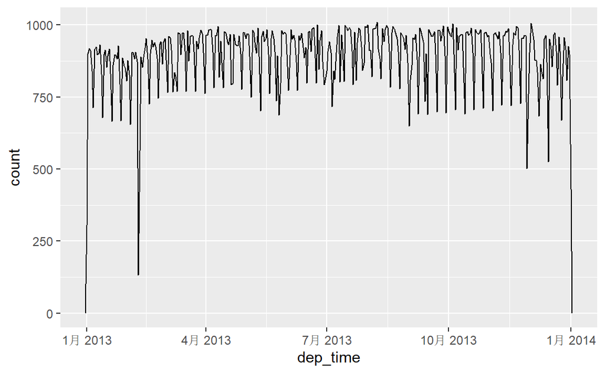

```r
# 以天为宽度汇总起飞航班的频数
flights_dt %>%
  ggplot(aes(dep_time)) +
  geom_freqpoly(binwidth = 86400)
```

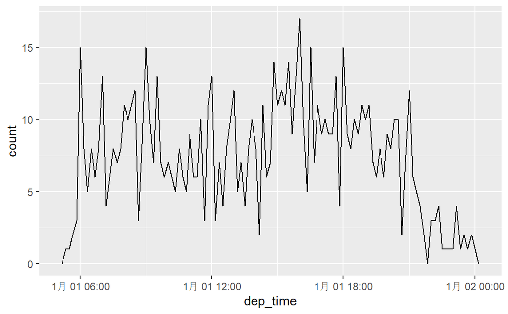

```r
# 86400秒 = 1天，由于横轴是日期时间型数据，1代表1秒

# 以10分钟为宽度，汇总2013年1月1日起飞航班的频数
flights_dt %>%
  filter(dep_time < ymd(20130102)) %>%
  ggplot(aes(dep_time)) +
  geom_freqpoly(binwidth = 600) # 600秒 = 10分钟
```